# joins

# nycflights13

For this exercises, we will use four tibbles that are related to the “flight” table you used before.

Check out the 4 tibbles before jumping to the question.

“airlines”, “airports”, “planes”, “weather” (How many points they have) (create issues for each questions. then github flow )

# For the questions below, create an issue for each of them in the github and close the issue when you finished the problem.

```r
flights
```

```
## # A tibble: 336,776 × 19
##     year month   day dep_time sched_dep_time dep_delay arr_time sched_arr_time
##    <int> <int> <int>    <int>          <int>     <dbl>    <int>          <int>
##  1  2013     1     1      517            515         2      830            819
##  2  2013     1     1      533            529         4      850            830
##  3  2013     1     1      542            540         2      923            850
##  4  2013     1     1      544            545        -1     1004           1022
##  5  2013     1     1      554            600        -6      812            837
##  6  2013     1     1      554            558        -4      740            728
##  7  2013     1     1      555            600        -5      913            854
##  8  2013     1     1      557            600        -3      709            723
##  9  2013     1     1      557            600        -3      838            846
## 10  2013     1     1      558            600        -2      753            745
## # … with 336,766 more rows, and 11 more variables: arr_delay <dbl>,
## #   carrier <chr>, flight <int>, tailnum <chr>, origin <chr>, dest <chr>,
## #   air_time <dbl>, distance <dbl>, hour <dbl>, minute <dbl>, time_hour <dttm>
```

```r
airlines
```

```
## # A tibble: 16 × 2
##    carrier name
##    <chr>   <chr>
##  1 9E      Endeavor Air Inc.
##  2 AA      American Airlines Inc.
##  3 AS      Alaska Airlines Inc.
##  4 B6      JetBlue Airways
##  5 DL      Delta Air Lines Inc.
##  6 EV      ExpressJet Airlines Inc.
##  7 F9      Frontier Airlines Inc.
##  8 FL      AirTran Airways Corporation
##  9 HA      Hawaiian Airlines Inc.
## 10 MQ      Envoy Air
## 11 OO      SkyWest Airlines Inc.
## 12 UA      United Air Lines Inc.
## 13 US      US Airways Inc.
## 14 VX      Virgin America
## 15 WN      Southwest Airlines Co.
## 16 YV      Mesa Airlines Inc.
```

```r
airports
```

```
## # A tibble: 1,458 × 8
##    faa   name                             lat    lon   alt    tz dst   tzone
##    <chr> <chr>                          <dbl>  <dbl> <dbl> <dbl> <chr> <chr>
##  1 04G   Lansdowne Airport               41.1  -80.6  1044    -5 A     America/…
##  2 06A   Moton Field Municipal Airport   32.5  -85.7   264    -6 A     America/…
##  3 06C   Schaumburg Regional             42.0  -88.1   801    -6 A     America/…
##  4 06N   Randall Airport                 41.4  -74.4   523    -5 A     America/…
##  5 09J   Jekyll Island Airport           31.1  -81.4    11    -5 A     America/…
##  6 0A9   Elizabethton Municipal Airport  36.4  -82.2  1593    -5 A     America/…
##  7 0G6   Williams County Airport         41.5  -84.5   730    -5 A     America/…
##  8 0G7   Finger Lakes Regional Airport   42.9  -76.8   492    -5 A     America/…
##  9 0P2   Shoestring Aviation Airfield    39.8  -76.6  1000    -5 U     America/…
## 10 0S9   Jefferson County Intl           48.1 -123.    108    -8 A     America/…
## # … with 1,448 more rows
```

```r
planes
```

```
## # A tibble: 3,322 × 9
##    tailnum  year type          manufacturer   model  engines seats speed engine
##    <chr>   <int> <chr>         <chr>          <chr>    <int> <int> <int> <chr>
##  1 N10156   2004 Fixed wing m… EMBRAER        EMB-1…       2    55    NA Turbo-…
##  2 N102UW   1998 Fixed wing m… AIRBUS INDUST… A320-…       2   182    NA Turbo-…
##  3 N103US   1999 Fixed wing m… AIRBUS INDUST… A320-…       2   182    NA Turbo-…
##  4 N104UW   1999 Fixed wing m… AIRBUS INDUST… A320-…       2   182    NA Turbo-…
##  5 N10575   2002 Fixed wing m… EMBRAER        EMB-1…       2    55    NA Turbo-…
##  6 N105UW   1999 Fixed wing m… AIRBUS INDUST… A320-…       2   182    NA Turbo-…
##  7 N107US   1999 Fixed wing m… AIRBUS INDUST… A320-…       2   182    NA Turbo-…
##  8 N108UW   1999 Fixed wing m… AIRBUS INDUST… A320-…       2   182    NA Turbo-…
##  9 N109UW   1999 Fixed wing m… AIRBUS INDUST… A320-…       2   182    NA Turbo-…
## 10 N110UW   1999 Fixed wing m… AIRBUS INDUST… A320-…       2   182    NA Turbo-…
## # … with 3,312 more rows
```

```r
weather
```

```
## # A tibble: 26,115 × 15
##    origin  year month   day  hour  temp  dewp humid wind_dir wind_speed
##    <chr>  <int> <int> <int> <int> <dbl> <dbl> <dbl>    <dbl>      <dbl>
##  1 EWR     2013     1     1     1  39.0  26.1  59.4      270      10.4
##  2 EWR     2013     1     1     2  39.0  27.0  61.6      250       8.06
##  3 EWR     2013     1     1     3  39.0  28.0  64.4      240      11.5
##  4 EWR     2013     1     1     4  39.9  28.0  62.2      250      12.7
##  5 EWR     2013     1     1     5  39.0  28.0  64.4      260      12.7
##  6 EWR     2013     1     1     6  37.9  28.0  67.2      240      11.5
##  7 EWR     2013     1     1     7  39.0  28.0  64.4      240      15.0
##  8 EWR     2013     1     1     8  39.9  28.0  62.2      250      10.4
##  9 EWR     2013     1     1     9  39.9  28.0  62.2      260      15.0
## 10 EWR     2013     1     1    10  41    28.0  59.6      260      13.8
## # … with 26,105 more rows, and 5 more variables: wind_gust <dbl>, precip <dbl>,
## #   pressure <dbl>, visib <dbl>, time_hour <dttm>
```

## Question 1 : Exercises for relations data (20 pts)

1. Imagine you wanted to draw (approximately) the route each plane flies from its origin to its destination. What variables would you need? What tables would you need to combine? (You dont need to write code for this question.)

Answers: To draw the route of each plane, I need “origin airport”, “destination airport”, “latitude”, “longitude” and “altitude”(if 3D). I need to combine the tables “flights” and “airport”. `origin` and `dest` are from “flights”, and `faa`, `lat`, `lon`, `alt` are from “airports”.

2. We know that some days of the year are “special”, and fewer people than usual fly on them. How might you represent that data as a data frame? What would be the primary keys of that table?

Answers: Some special dates are festivals and I will list “New Years Day”, “Independence Day”, “Columbus Day”, “Thanksgiving Day” and “Christmas Day” as a data frame. And use the “year”,“month” and “day” to join with other data frames. Btw, the “year”,“month” and “day” would be the primary keys of that table. And then, the data frame would be represented below.

```r
festivals <- data.frame(
                        year = c(2013, 2013, 2013, 2013, 2013),
                        month = c(1, 7, 10, 11, 12),
                        day = c(1, 4, 14, 29, 25),
                        festival = c("New Year", "Independence Day", "Columbus Day", "Thanksgiving Day", "Christmas Day"))
festivals
```

```
##   year month day         festival
## 1 2013     1   1         New Year
## 2 2013     7   4 Independence Day
## 3 2013    10  14     Columbus Day
## 4 2013    11  29 Thanksgiving Day
## 5 2013    12  25    Christmas Day
```

## Question 2: Exercises for Keys (10 pts)

1. What are the primary keys of the 4 tibbles? Can you write code to verify that your assumptions are correct? (Hint: One way to do that is to count() the primary keys and look for entries where n is greater than one.)

Answers:

1.1 The primary key of “airlines” is`carrier`.

```r
airlines %>%
  count(carrier) %>%
  filter(n>1)
```

```
## # A tibble: 0 × 2
## # … with 2 variables: carrier <chr>, n <int>
```

1.2 The primary key of “airports” is`faa`.

```r
airports %>%
  count(faa) %>%
  filter(n>1)
```

```
## # A tibble: 0 × 2
## # … with 2 variables: faa <chr>, n <int>
```

1.3 The primary key of “planes” is `tailnum`.

```r
planes %>%
  count(tailnum) %>%
  filter(n>1)
```

```
## # A tibble: 0 × 2
## # … with 2 variables: tailnum <chr>, n <int>
```

1.4 The primary key of “weather” are `origin` and `time_hour`.

```r
weather %>%
  count(origin, time_hour) %>%
  filter(n>1)
```

```
## # A tibble: 0 × 3
## # … with 3 variables: origin <chr>, time_hour <dttm>, n <int>
```

I verified those 1.1:1.3 and the results are 0, so I made correct assumptions. But in the last one, I firstly chose only `time_hour`, so after filtering, the result is not 0. And then I add `origin` into the code, so everything goes alright.

## Question 3: Exercises for Joins (50 pts)

1. Compute the average delay by destination, then join on the airports data frame so you can show the spatial distribution of delays. Here’s an easy way to draw a map of the United States:

airports %>% semi_join(flights, c(“faa” = “dest”)) %>% ggplot(aes(lon, lat)) + borders(“state”) + geom_point() + coord_quickmap()

Think about how you add to this code to create your map.

You might want to use the size or colour of the points to display the average delay for each airport.

Answers:

```r
ave_delay_by_dest <- flights %>%
  group_by(dest) %>%
  summarise(ave_delay = mean(arr_delay, na.rm = TRUE))%>%
  left_join(airports,by = c("dest"="faa"))
ave_delay_by_dest
```

```
## # A tibble: 105 × 9
##    dest  ave_delay name                  lat    lon   alt    tz dst   tzone
##    <chr>     <dbl> <chr>               <dbl>  <dbl> <dbl> <dbl> <chr> <chr>
##  1 ABQ        4.38 Albuquerque Intern…  35.0 -107.   5355    -7 A     America/D…
##  2 ACK        4.85 Nantucket Mem        41.3  -70.1    48    -5 A     America/N…
##  3 ALB       14.4  Albany Intl          42.7  -73.8   285    -5 A     America/N…
##  4 ANC       -2.5  Ted Stevens Anchor…  61.2 -150.    152    -9 A     America/A…
##  5 ATL       11.3  Hartsfield Jackson…  33.6  -84.4  1026    -5 A     America/N…
##  6 AUS        6.02 Austin Bergstrom I…  30.2  -97.7   542    -6 A     America/C…
##  7 AVL        8.00 Asheville Regional…  35.4  -82.5  2165    -5 A     America/N…
##  8 BDL        7.05 Bradley Intl         41.9  -72.7   173    -5 A     America/N…
##  9 BGR        8.03 Bangor Intl          44.8  -68.8   192    -5 A     America/N…
## 10 BHM       16.9  Birmingham Intl      33.6  -86.8   644    -6 A     America/C…
## # … with 95 more rows
```

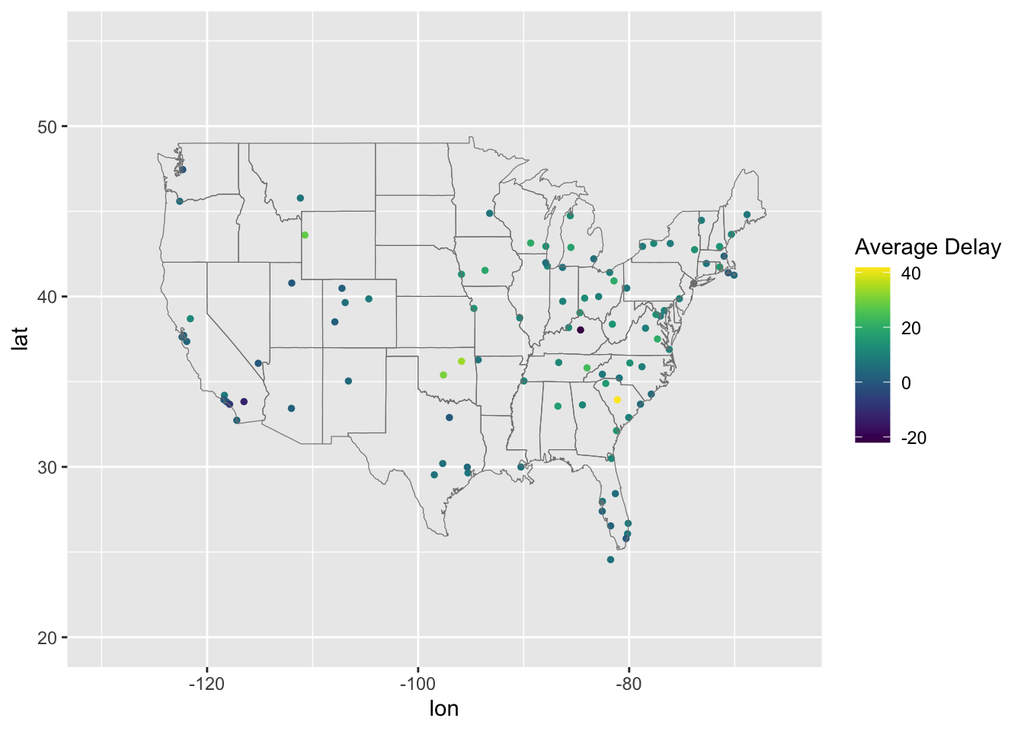

```r
ave_delay_by_dest %>%
  ggplot(aes(
             y = lat,
             x = lon,
             color = ave_delay,
             size = ave_delay)) +
  labs(color = "Average Delay") +
  geom_point(
             size = 1,
             alpha = 5 ) +
  borders("state",
          size = 0.2,
          alpha = 0.5 ) +
  coord_quickmap() +
  coord_cartesian(xlim = c(-130,-65),
                  ylim = c(20,55)) +
  viridis::scale_color_viridis()
```

2. Filter flights to only show flights with planes that have flown at least 100 flights. (You will first need to find the planes that have flown at least 100 flights.)

Report how many flight in total after filtering in your output.

Answers:

```r
flights_more_than_100 <- flights %>%
  count(tailnum) %>%
  filter(n >= 100) %>%
  na.omit
flights_more_than_100
```

```
## # A tibble: 1,217 × 2
##    tailnum     n
##    <chr>   <int>
##  1 N0EGMQ    371
##  2 N10156    153
##  3 N10575    289
##  4 N11106    129
##  5 N11107    148
##  6 N11109    148
##  7 N11113    138
##  8 N11119    148
##  9 N11121    154
## 10 N11127    124
## # … with 1,207 more rows
```

```r
flights%>%
  semi_join(flights_more_than_100, by = "tailnum") %>%
  nrow()
```

```
## [1] 228390
```

3. What does anti_join(flights, airports, by = c(“dest” = “faa”)) tell you? What does anti_join(airports, flights, by = c(“faa” = “dest”)) tell you?

Answers:

```r
flights
```

```
## # A tibble: 336,776 × 19
##     year month   day dep_time sched_dep_time dep_delay arr_time sched_arr_time
##    <int> <int> <int>    <int>          <int>     <dbl>    <int>          <int>
##  1  2013     1     1      517            515         2      830            819
##  2  2013     1     1      533            529         4      850            830
##  3  2013     1     1      542            540         2      923            850
##  4  2013     1     1      544            545        -1     1004           1022
##  5  2013     1     1      554            600        -6      812            837
##  6  2013     1     1      554            558        -4      740            728
##  7  2013     1     1      555            600        -5      913            854
##  8  2013     1     1      557            600        -3      709            723
##  9  2013     1     1      557            600        -3      838            846
## 10  2013     1     1      558            600        -2      753            745
## # … with 336,766 more rows, and 11 more variables: arr_delay <dbl>,
## #   carrier <chr>, flight <int>, tailnum <chr>, origin <chr>, dest <chr>,
## #   air_time <dbl>, distance <dbl>, hour <dbl>, minute <dbl>, time_hour <dttm>
```

```r
airports
```

```
## # A tibble: 1,458 × 8
##    faa   name                             lat    lon   alt    tz dst   tzone
##    <chr> <chr>                          <dbl>  <dbl> <dbl> <dbl> <chr> <chr>
##  1 04G   Lansdowne Airport               41.1  -80.6  1044    -5 A     America/…
##  2 06A   Moton Field Municipal Airport   32.5  -85.7   264    -6 A     America/…
##  3 06C   Schaumburg Regional             42.0  -88.1   801    -6 A     America/…
##  4 06N   Randall Airport                 41.4  -74.4   523    -5 A     America/…
##  5 09J   Jekyll Island Airport           31.1  -81.4    11    -5 A     America/…
##  6 0A9   Elizabethton Municipal Airport  36.4  -82.2  1593    -5 A     America/…
##  7 0G6   Williams County Airport         41.5  -84.5   730    -5 A     America/…
##  8 0G7   Finger Lakes Regional Airport   42.9  -76.8   492    -5 A     America/…
##  9 0P2   Shoestring Aviation Airfield    39.8  -76.6  1000    -5 U     America/…
## 10 0S9   Jefferson County Intl           48.1 -123.    108    -8 A     America/…
## # … with 1,448 more rows
```

```r
anti_join(flights, airports, by = c("dest" = "faa"))
```

```
## # A tibble: 7,602 × 19
##     year month   day dep_time sched_dep_time dep_delay arr_time sched_arr_time
##    <int> <int> <int>    <int>          <int>     <dbl>    <int>          <int>
##  1  2013     1     1      544            545        -1     1004           1022
##  2  2013     1     1      615            615         0     1039           1100
##  3  2013     1     1      628            630        -2     1137           1140
##  4  2013     1     1      701            700         1     1123           1154
##  5  2013     1     1      711            715        -4     1151           1206
##  6  2013     1     1      820            820         0     1254           1310
##  7  2013     1     1      820            820         0     1249           1329
##  8  2013     1     1      840            845        -5     1311           1350
##  9  2013     1     1      909            810        59     1331           1315
## 10  2013     1     1      913            918        -5     1346           1416
## # … with 7,592 more rows, and 11 more variables: arr_delay <dbl>,
## #   carrier <chr>, flight <int>, tailnum <chr>, origin <chr>, dest <chr>,
## #   air_time <dbl>, distance <dbl>, hour <dbl>, minute <dbl>, time_hour <dttm>
```

It tells us the flights in “flights” table whose `dest` are not included in in “airports” table. It is equivalent to `filter` the `dest` which “airports” table doesn’t have and shows every variable that “flights” table has.

```r
flights
```

```
## # A tibble: 336,776 × 19
##     year month   day dep_time sched_dep_time dep_delay arr_time sched_arr_time
##    <int> <int> <int>    <int>          <int>     <dbl>    <int>          <int>
##  1  2013     1     1      517            515         2      830            819
##  2  2013     1     1      533            529         4      850            830
##  3  2013     1     1      542            540         2      923            850
##  4  2013     1     1      544            545        -1     1004           1022
##  5  2013     1     1      554            600        -6      812            837
##  6  2013     1     1      554            558        -4      740            728
##  7  2013     1     1      555            600        -5      913            854
##  8  2013     1     1      557            600        -3      709            723
##  9  2013     1     1      557            600        -3      838            846
## 10  2013     1     1      558            600        -2      753            745
## # … with 336,766 more rows, and 11 more variables: arr_delay <dbl>,
## #   carrier <chr>, flight <int>, tailnum <chr>, origin <chr>, dest <chr>,
## #   air_time <dbl>, distance <dbl>, hour <dbl>, minute <dbl>, time_hour <dttm>
```

```r
airports
```

```
## # A tibble: 1,458 × 8
##    faa   name                             lat    lon   alt    tz dst   tzone
##    <chr> <chr>                          <dbl>  <dbl> <dbl> <dbl> <chr> <chr>
##  1 04G   Lansdowne Airport               41.1  -80.6  1044    -5 A     America/…
##  2 06A   Moton Field Municipal Airport   32.5  -85.7   264    -6 A     America/…
##  3 06C   Schaumburg Regional             42.0  -88.1   801    -6 A     America/…
##  4 06N   Randall Airport                 41.4  -74.4   523    -5 A     America/…
##  5 09J   Jekyll Island Airport           31.1  -81.4    11    -5 A     America/…
##  6 0A9   Elizabethton Municipal Airport  36.4  -82.2  1593    -5 A     America/…
##  7 0G6   Williams County Airport         41.5  -84.5   730    -5 A     America/…
##  8 0G7   Finger Lakes Regional Airport   42.9  -76.8   492    -5 A     America/…
##  9 0P2   Shoestring Aviation Airfield    39.8  -76.6  1000    -5 U     America/…
## 10 0S9   Jefferson County Intl           48.1 -123.    108    -8 A     America/…
## # … with 1,448 more rows
```

```r
anti_join(airports, flights, by = c("faa" = "dest"))
```

```
## # A tibble: 1,357 × 8
##    faa   name                             lat    lon   alt    tz dst   tzone
##    <chr> <chr>                          <dbl>  <dbl> <dbl> <dbl> <chr> <chr>
##  1 04G   Lansdowne Airport               41.1  -80.6  1044    -5 A     America/…
##  2 06A   Moton Field Municipal Airport   32.5  -85.7   264    -6 A     America/…
##  3 06C   Schaumburg Regional             42.0  -88.1   801    -6 A     America/…
##  4 06N   Randall Airport                 41.4  -74.4   523    -5 A     America/…
##  5 09J   Jekyll Island Airport           31.1  -81.4    11    -5 A     America/…
##  6 0A9   Elizabethton Municipal Airport  36.4  -82.2  1593    -5 A     America/…
##  7 0G6   Williams County Airport         41.5  -84.5   730    -5 A     America/…
##  8 0G7   Finger Lakes Regional Airport   42.9  -76.8   492    -5 A     America/…
##  9 0P2   Shoestring Aviation Airfield    39.8  -76.6  1000    -5 U     America/…
## 10 0S9   Jefferson County Intl           48.1 -123.    108    -8 A     America/…
## # … with 1,347 more rows
```

It tells us the airports in “airports” table whose `faa` are not included in in “flights” table. It is equivalent to `filter` the `faa` which “flights” table doesn’t have and shows every variable that “airports” table has.